# Python script for DisoMine API

## Converting FASTA format to Json

##### This web APIs support only JSON format so converting FASTA to JSON formatted file is required.

##### The "json" module is imported at the top.

### The fasta2json Function:

###### Accepts a FASTA file as input and return a JSON file as output.

###### 1. A FASTA file is accepted as an input.

###### 2. Readonf the first line of the file.

###### 3. If the line starts with ">" it will be saved as a list variable called "active_sequence_name"

##### The line will be saved as a list variable called "sequence".

##### This step will be repeated until the end of the file and the sequences are appended to the end of the two list variables

###### 4. The variables (active_sequence_name and sequence) will be saved in a text file called "ProSeqJson.json".

```python
import json

# A function for converting FASTA to JSON.
def fasta2json(input_file):

    # defining a dictinary called fasta
    fasta = {}

    # opening the input file and reading each line
    with open(input_file) as file_one:
        for line in file_one:
            line = line.strip()
            if not line:
                continue

            # Defining the condition for the sequence name
            if line.startswith(">"):
                active_sequence_name = line[1:]

                # Defining the condition for the sequence
                if active_sequence_name not in fasta:
                    fasta[active_sequence_name] = []
                continue
            sequence = line
            fasta[active_sequence_name].append(sequence)

    # Defining a variable fasta_j as a json
    fasta_j = json.loads(json.dumps(fasta))

    # Saving the fasta_j in an output file
    with open('ProSeqJson.json', 'w+') as outfile:
        json.dump(fasta_j, outfile, indent = 2)

fasta2json('/Users/Niloofar/Desktop/Jupyter/inputProSeqFasta.fasta')
```

## Getting data from DisoMine

#### The "requests" and "json" modules are imported.

### The getDataFromDisoMine Function

###### 1. It accepted a JSON file as an input and read the file.

###### 2. Defining a variable for our API URL.

###### 3. Making POST request with JSON input body using "post".It accepts two urguments: I) API URL, and II) JSON file

###### 4. Validating the response using status_code (Status 202 indicates that request has been accepted for processing)

##### 5. Making GET request to check queue request status.

```python
import requests
import json

def getDataFromDisoMine():

    # Read input Json file
    file = open('/Users/Niloofar/Desktop/Jupyter/ProSeqJson.json', 'r')
    input = file.read()
    request_json = json.loads(input)

    # API Post URL
    post_url = "http://bio2byte.com/disomine/api/"

    # Make POST request with Json Input body
    response = requests.post(post_url, request_json)

    # Validating Response Code
    assert response.status_code == 202

    # Get Request
    get_url = "http://ibsquare.be/disomine/api/queue/"
    requests.get(get_url + str(response.json()['queue_id']))
    print(response.content)

getDataFromDisoMine()
```

```
b'{"message":"We are processing your request, check queue to be updated about the processing status","Location":"/api/queue/98/","queue_id":98}'
```

### A bash file for API call

#### Runing the bash file using bash command (bash /.../disomine.sh)

```python
!bash disomine.sh

#..................
#!/bin/bash
#http POST http://bio2byte.com/disomine/api < /Users/Niloofar/Desktop/TrainingSessionAPI/example_toy.json
#..................
```

```
HTTP/1.1 202 Accepted
Allow: GET, POST, HEAD, OPTIONS
Connection: keep-alive
Content-Length: 143
Content-Type: application/json
Date: Wed, 30 Jan 2019 14:35:51 GMT
Location: /api/queue/116/
Server: nginx/1.10.3 (Ubuntu)
Vary: Accept, Cookie
X-Frame-Options: SAMEORIGIN
model: request


{
    "Location": "/api/queue/116/",
    "message": "We are processing your request, check queue to be updated about the processing status",
    "queue_id": 116
}
```

# Python script for DynaMine API

## Getting data from DynaMine

#### Creating a JSON interface which accept a json_api_key. It has six methods:

###### a. submit_sequence: this method accepts sequence of protein (proteins) and the boolian prediction_only

###### b. submit_uniprot_ids: this method accepts uniprot_ids and the boolian prediction_only

```python
"""
Created by Elisa Cilia on 2014-08-20.
Copyright (c) 2014 Elisa Cilia. All rights reserved.
"""

import json
import urllib.request, urllib.parse, urllib.error
import time
import sys


# creating a JSON interface

class DynaMineJSONInterface:

    def __init__(self, json_api_key):
        self._running = False
        self._json_api_key = '3469626345366a923473c455fd6bb283621e70a3ba5428f301501f8a'

    def submit_sequences(self, proteins, predictions_only=True):
        job = {'protocol': '1.0',
               'json_api_key': self._json_api_key,
               'sequences': proteins,
               'predictions_only': predictions_only,
               }
        return self._submit_job(job)

    def submit_uniprot_ids(self, uniprot_ids, predictions_only=True):
        job = {'protocol': '1.0',
               'json_api_key': self._json_api_key,
               'uniprot_ids': uniprot_ids,
               'predictions_only': predictions_only,
               }
        return self._submit_job(job)

    def _submit_job(self, job):
        # response gives us a job_id
        response = self._dynamine_request(job)
        if response['status'] == 'error':
            sys.stderr.write(response['message'] + '\n')
            sys.exit(1)
        job_id = response['job_id']
        self._print_progress(response['status'], False)
        # this makes the call blocking until the results are ready
        while response['status'] != 'completed':
            time.sleep(1.5)
            response = self._poll_results(job_id)
            if response['status'] == 'error':
                sys.stderr.write(response['message'] + '\n')
                sys.exit(1)
            self._print_progress(response['status'], True)
        return response['results']

    def _dynamine_request(self, request):
        # this is the post request with the json encoding of the job
        data = urllib.parse.urlencode({'batch': json.dumps(request)}).encode("utf-8")
        url = 'http://dynamine.ibsquare.be/batch_request'
        response = ''

        req = urllib.request.Request(url, data)
        http_response = urllib.request.urlopen(req)
        response = json.loads(http_response.read())

        #response = {'status': 'error', 'message': 'Unable to communicate with the server.Please verify that %s is up and running, otherwise concact the server administrator (ERROR: %s).'}

        return response

    def _poll_results(self, job_id):
        request = {'protocol': '1.0',
                   'json_api_key': self._json_api_key,
                   'job_id': job_id
                   }
        return self._dynamine_request(request)

    def _print_progress(self, status, flag):
        if status == 'queued':
            if flag:
                sys.stdout.write('Waiting to be processed.\n')
            else:
                sys.stdout.write('The request has been submitted.\n')
            self._running = False
        elif status == 'running':
            if not self._running:
                self._running = True
                sys.stdout.write('The request is being processed...')
            else:
                sys.stdout.write('.')
        elif status == 'completed':
            if not self._running:
                sys.stdout.write('The request is being processed...')
            sys.stdout.write('done.\n')
        elif status == 'error':
            sys.stderr.write('\n\nError while processing the request:\n\n')
        sys.stdout.flush()


if __name__ == '__main__':
    json_api_key = 'd03e71ca849d3bc5277fd68e7a0f45124df5be84bf348db65218982f'
    dynamine = DynaMineJSONInterface(json_api_key)

    proteins = {'sp|P04637|P53_HUMAN':
                    '''MEEPQSDPSVEPPLSQETFSDLWKLLPENNVLSPLPSQAMDDLMLSPDDIEQWFTEDPGP
                    DEAPRMPEAAPPVAPAPAAPTPAAPAPAPSWPLSSSVPSQKTYQGSYGFRLGFLHSGTAK
                    SVTCTYSPALNKMFCQLAKTCPVQLWVDSTPPPGTRVRAMAIYKQSQHMTEVVRRCPHHE
                    RCSDSDGLAPPQHLIRVEGNLRVEYLDDRNTFRHSVVVPYEPPEVGSDCTTIHYNYMCNS
                    SCMGGMNRRPILTIITLEDSSGNLLGRNSFEVRVCACPGRDRRTEEENLRKKGEPHHELP
                    PGSTKRALPNNTSSSPQPKKKPLDGEYFTLQIRGRERFEMFRELNEALELKDAQAGKEPG
                    GSRAHSSHLKSKKGQSTSRHKKLMFKTEGPDSD''',
                'sp|Q92793|CBP_HUMAN':
                    '''MAENLLDGPPNPKRAKLSSPGFSANDSTDFGSLFDLENDLPDELIPNGGELGLLNSGNLV
                    PDAASKHKQLSELLRGGSGSSINPGIGNVSASSPVQQGLGGQAQGQPNSANMASLSAMGK
                    SPLSQGDSSAPSLPKQAASTSGPTPAASQALNPQAQKQVGLATSSPATSQTGPGICMNAN
                    FNQTHPGLLNSNSGHSLINQASQGQAQVMNGSLGAAGRGRGAGMPYPTPAMQGASSSVLA
                    ETLTQVSPQMTGHAGLNTAQAGGMAKMGITGNTSPFGQPFSQAGGQPMGATGVNPQLASK
                    QSMVNSLPTFPTDIKNTSVTNVPNMSQMQTSVGIVPTQAIATGPTADPEKRKLIQQQLVL
                    LLHAHKCQRREQANGEVRACSLPHCRTMKNVLNHMTHCQAGKACQVAHCASSRQIISHWK
                    NCTRHDCPVCLPLKNASDKRNQQTILGSPASGIQNTIGSVGTGQQNATSLSNPNPIDPSS
                    MQRAYAALGLPYMNQPQTQLQPQVPGQQPAQPQTHQQMRTLNPLGNNPMNIPAGGITTDQ
                    QPPNLISESALPTSLGATNPLMNDGSNSGNIGTLSTIPTAAPPSSTGVRKGWHEHVTQDL
                    RSHLVHKLVQAIFPTPDPAALKDRRMENLVAYAKKVEGDMYESANSRDEYYHLLAEKIYK
                    IQKELEEKRRSRLHKQGILGNQPALPAPGAQPPVIPQAQPVRPPNGPLSLPVNRMQVSQG
                    MNSFNPMSLGNVQLPQAPMGPRAASPMNHSVQMNSMGSVPGMAISPSRMPQPPNMMGAHT
                    NNMMAQAPAQSQFLPQNQFPSSSGAMSVGMGQPPAQTGVSQGQVPGAALPNPLNMLGPQA
                    SQLPCPPVTQSPLHPTPPPASTAAGMPSLQHTTPPGMTPPQPAAPTQPSTPVSSSGQTPT
                    PTPGSVPSATQTQSTPTVQAAAQAQVTPQPQTPVQPPSVATPQSSQQQPTPVHAQPPGTP
                    LSQAAASIDNRVPTPSSVASAETNSQQPGPDVPVLEMKTETQAEDTEPDPGESKGEPRSE
                    MMEEDLQGASQVKEETDIAEQKSEPMEVDEKKPEVKVEVKEEEESSSNGTASQSTSPSQP
                    RKKIFKPEELRQALMPTLEALYRQDPESLPFRQPVDPQLLGIPDYFDIVKNPMDLSTIKR
                    KLDTGQYQEPWQYVDDVWLMFNNAWLYNRKTSRVYKFCSKLAEVFEQEIDPVMQSLGYCC
                    GRKYEFSPQTLCCYGKQLCTIPRDAAYYSYQNRYHFCEKCFTEIQGENVTLGDDPSQPQT
                    TISKDQFEKKKNDTLDPEPFVDCKECGRKMHQICVLHYDIIWPSGFVCDNCLKKTGRPRK
                    ENKFSAKRLQTTRLGNHLEDRVNKFLRRQNHPEAGEVFVRVVASSDKTVEVKPGMKSRFV
                    DSGEMSESFPYRTKALFAFEEIDGVDVCFFGMHVQEYGSDCPPPNTRRVYISYLDSIHFF
                    RPRCLRTAVYHEILIGYLEYVKKLGYVTGHIWACPPSEGDDYIFHCHPPDQKIPKPKRLQ
                    EWYKKMLDKAFAERIIHDYKDIFKQATEDRLTSAKELPYFEGDFWPNVLEESIKELEQEE
                    EERKKEESTAASETTEGSQGDSKNAKKKNNKKTNKNKSSISRANKKKPSMPNVSNDLSQK
                    LYATMEKHKEVFFVIHLHAGPVINTLPPIVDPDPLLSCDLMDGRDAFLTLARDKHWEFSS
                    LRRSKWSTLCMLVELHTQGQDRFVYTCNECKHHVETRWHCTVCEDYDLCINCYNTKSHAH
                    KMVKWGLGLDDEGSSQGEPQSKSPQESRRLSIQRCIQSLVHACQCRNANCSLPSCQKMKR
                    VVQHTKGCKRKTNGGCPVCKQLIALCCYHAKHCQENKCPVPFCLNIKHKLRQQQIQHRLQ
                    QAQLMRRRMATMNTRNVPQQSLPSPTSAPPGTPTQQPSTPQTPQPPAQPQPSPVSMSPAG
                    FPSVARTQPPTTVSTGKPTSQVPAPPPPAQPPPAAVEAARQIEREAQQQQHLYRVNINNS
                    MPPGRTGMGTPGSQMAPVSLNVPRPNQVSGPVMPSMPPGQWQQAPLPQQQPMPGLPRPVI
                    SMQAQAAVAGPRMPSVQPPRSISPSALQDLLRTLKSPSSPQQQQQVLNILKSNPQLMAAF
                    IKQRTAKYVANQPGMQPQPGLQSQPGMQPQPGMHQQPSLQNLNAMQAGVPRPGVPPQQQA
                    MGGLNPQGQALNIMNPGHNPNMASMNPQYREMLRRQLLQQQQQQQQQQQQQQQQQQGSAG
                    MAGGMAGHGQFQQPQGPGGYPPAMQQQQRMQQHLPLQGSSMGQMAAQMGQLGQMGQPGLG
                    ADSTPNIQQALQQRILQQQQMKQQIGSPGQPNPMSPQQHMLSGQPQASHLPGQQIATSLS
                    NQVRSPAPVQSPRPQSQPPHSSPSPRIQPQPSPHHVSPQTGSPHPGLAVTMASSIDQGHL
                    GNPEQSAMLPQLNTPSRSALSSELSLVGDTTGDTLEKFVEGL'''
                }


    results = dynamine.submit_sequences(proteins, predictions_only=False)
    print()
    results

    uniprot_ids = ['P04637', 'P04638']
    results = dynamine.submit_uniprot_ids(uniprot_ids, predictions_only=True)
    print()
    results
```

```
The request has been submitted.
The request is being processed......done.

The request has been submitted.
The request is being processed...done.
```

## Plotting DisoMine, DynaMine and EFoldMine Result

### 1. Read the DisoMine result (JSON format)

### 2. Defining an index for each residue

### 3. Defing the corresponding DisoMine Scores for each residue

### 4. Creating the plot using figure, add_subplot and show.

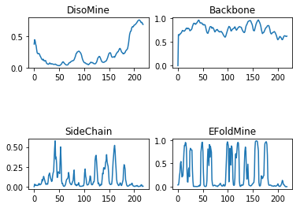

```python
import matplotlib.pyplot as plt
import numpy as np
import json

# Read input Json file
file = open('/Users/Niloofar/Desktop/TrainingSessionAPI/Disomine_backbone_sidechain_efoldmine.json', 'r')
input = file.read()
request_json = json.loads(input)

# creating a plot

# residue index
seq = request_json["results"][0]['sequence']

#DisoMine Score
disomine = request_json["results"][0]['disomine']

#backbone Score
backbone = request_json["results"][0]['backbone']

#sidechain Score
sidechain = request_json["results"][0]['sidechain']

#efoldmine Score
efoldmine = request_json["results"][0]['efoldmine']

#plots
fig = plt.figure()

#ploting the DisoMine results
axes = fig.add_subplot(321)
axes.plot(range(len(seq)), disomine)
axes.set_title("DisoMine")

#ploting the Backbone results
axes = fig.add_subplot(322)
axes.plot(range(len(seq)), backbone)
axes.set_title("Backbone")

#ploting the SideChain results
axes = fig.add_subplot(325)
axes.plot(range(len(seq)), sidechain)
axes.set_title("SideChain")

#ploting the EFoldMine results
axes = fig.add_subplot(326)
axes.plot(range(len(seq)), efoldmine)
axes.set_title("EFoldMine")

plt.show()
```

## Python script for DEOGEN2 API

### Getting data from DEOGEN2

```python
import requests
import json

def getDataFromDEOGEN2(sequence_id, mutation):

    # defining the api-endpoint
    api_endpoint = "https://deogen2.mutaframe.com/fetch_results.php"

    # API key
    key = 1524214674089
    sequence_id = sequence_id
    mutation = mutation
    structure_id = 0

    # data to be sent to api
    data = {
        " ": key,
        "sequence_id": sequence_id,
        "mutation": mutation,
        "structure_id": structure_id,
    }

    # Make POST request with Input body
    response = requests.get(api_endpoint, data)
    print(response.text)

    with open('DEOGEN2_1.json', 'w+') as outfile1:
        a = response.text
        d = json.loads(a)
        json.dump(d['all_deogen2'], outfile1, indent = 2)


    with open('DEOGEN2_2.json', 'w+') as outfile2:
        a = response.text
        d = json.loads(a)
        json.dump(d['deogen2'], outfile2, indent=2)


getDataFromDEOGEN2(64689, 'N45S')
```

[output not shown]

```python
import plotly
import plotly.plotly as py
import plotly.graph_objs as go
import json

# username and api_key for plot
plotly.tools.set_credentials_file(username='Niloofar_Sh', api_key='A8ruE4XKNDoxPg4nEHeI')

# Read input Json file
file = open('/Users/Niloofar/Desktop/TrainingSessionAPI/DisoMineResultSample.json', 'r')
input = file.read()
request_json = json.loads(input)

# creating a plot

# residue index
seq = request_json["results"][0]['sequence']

#DisoMine Score
disomine = request_json['results'][0]['disomine']

#plot
data = py.plot(range(len(seq)), disomine)
py.xaxis.title('Residue index')
py.ylabel('Score')
py.title('DisoMine Profile')
py.iplot(data, filename='jupyter-basic_bar')
```

[output not shown]